# eXtreme Gradient Boosting for Alzheimer’s Disease CSF Biomarker Discovery

Justin Taylor

May 10, 2016

# Data

Load the `AlzheimerDisease` data set from the AppliedPredictiveModeling package.

```r
data(AlzheimerDisease)
```

## Inspection

Dimensions: 333, 130

Number of rows = Number of labels: TRUE

Some variable names:

```r
colnames(head(predictors))
```

```
##   [1] "ACE_CD143_Angiotensin_Converti"   "ACTH_Adrenocorticotropic_Hormon"
##   [3] "AXL"                              "Adiponectin"
##   [5] "Alpha_1_Antichymotrypsin"         "Alpha_1_Antitrypsin"
##   [7] "Alpha_1_Microglobulin"            "Alpha_2_Macroglobulin"
##   [9] "Angiopoietin_2_ANG_2"             "Angiotensinogen"
##  [11] "Apolipoprotein_A_IV"              "Apolipoprotein_A1"
##  [13] "Apolipoprotein_A2"                "Apolipoprotein_B"
##  [15] "Apolipoprotein_CI"                "Apolipoprotein_CIII"
##  [17] "Apolipoprotein_D"                 "Apolipoprotein_E"
##  [19] "Apolipoprotein_H"                 "B_Lymphocyte_Chemoattractant_BL"
##  [21] "BMP_6"                            "Beta_2_Microglobulin"
##  [23] "Betacellulin"                     "C_Reactive_Protein"
##  [25] "CD40"                             "CD5L"
##  [27] "Calbindin"                        "Calcitonin"
##  [29] "CgA"                              "Clusterin_Apo_J"
```

[output cut: 50 more lines]

Variable types:

```r
sapply(predictors, class) %>% table
```

```
## .
##  factor integer numeric
##       1       2     127
```

Head of selected variables:

```r
head(predictors[,1:5])
```

```
##   ACE_CD143_Angiotensin_Converti ACTH_Adrenocorticotropic_Hormon
## 1                      2.0031003                       -1.386294
## 2                      1.5618560                       -1.386294
## 3                      1.5206598                       -1.714798
## 4                      1.6808260                       -1.609438
## 5                      2.4009308                       -0.967584
## 6                      0.4311565                       -1.272966
##          AXL Adiponectin Alpha_1_Antichymotrypsin
## 1  1.0983867   -5.360193                 1.740466
## 2  0.6832816   -5.020686                 1.458615
## 3 -0.1452763   -5.809143                 1.193922
## 4  0.6832816   -5.115996                 1.280934
## 5  0.1908902   -4.779524                 2.128232
## 6 -0.2223611   -5.221356                 1.308333
```

```r
ad_matrix <- as.matrix(sapply(predictors, as.numeric))
```

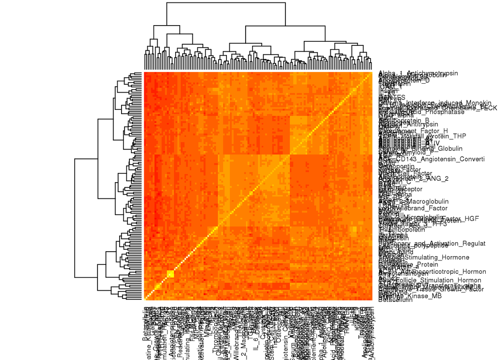

```r
heatmap(cor(ad_matrix))
```

The `label` parameter for `xgboost` should be $0$ or $1$ for binary classification.

```r
diagnosis <- parallel::mclapply(diagnosis, function(x) (
  if (x == "Control") (0) else 1
)) %>% unlist; head(diagnosis)
```

```
## [1] 0 0 0 0 0 1
```

## Preview

```r
DT::datatable(apply(ad_matrix, 2, round, 3), extensions = c('Responsive'))
```

| ACE_CD143_Angiotensin_Converti | ACTH_Adrenocorticotropic_Hormon | AXL | Adiponectin | Alpha_1_Antichymotrypsin | Alpha_1_Antitrypsin | Alpha_1_Microglobulin | Alpha_2_Macroglobulin | Angiopoietin_2_ANG_2 | Angiotensinogen | Apolipoprotein_A_IV | Apolipoprotein_A1 | Apolipoprotein_A2 | Apolipoprotein_B | Apolipoprotein_CI | Apolipoprotein_CIII | Apolipoprotein_D | Apolipoprotein_E | Apolipoprotein_H | B_Lymphocyte_Chemoattractant_BL | BMP_6 | Beta_2_Microglobulin | Betacellulin | C_Reactive_Protein | CD40 | CD5L | Calbindin | Calcitonin | CgA | Clusterin_Apo_J | … |
| --- | --- | --- | --- | --- | --- | --- | --- | --- | --- | --- | --- | --- | --- | --- | --- | --- | --- | --- | --- | --- | --- | --- | --- | --- | --- | --- | --- | --- | --- | --- |
| 2.003 | -1.386 | 1.098 | -5.36 | 1.74 | -12.631 | -2.577 | -72.65 | 1.065 | 2.511 | -1.427 | -7.402 | -0.261 | -4.624 | -1.273 | -2.313 | 2.079 | 3.755 | -0.157 | 2.297 | -2.201 | 0.693 | 34 | -4.075 | -0.796 | 0.095 | 33.214 | 1.386 | 397.654 | 3.555 | … |
| 1.562 | -1.386 | 0.683 | -5.021 | 1.459 | -11.91 | -3.244 | -154.612 | 0.742 | 2.457 | -1.661 | -7.047 | -0.868 | -6.748 | -1.273 | -2.343 | 1.335 | 3.097 | -0.575 | 1.673 | -1.728 | 0.47 | 53 | -6.645 | -1.273 | -0.673 | 25.276 | 3.611 | 465.676 | 3.045 | … |
| 1.521 | -1.715 | -0.145 | -5.809 | 1.194 | -13.643 | -2.882 | -136.529 | 0.833 | 1.976 | -1.661 | -7.684 | -0.654 | -3.976 | -1.715 | -2.749 | 1.335 | 2.753 | -0.345 | 1.673 | -2.062 | 0.336 | 49 | -8.047 | -1.242 | 0.095 | 22.166 | 2.116 | 347.864 | 2.773 | … |
| 1.681 | -1.609 | 0.683 | -5.116 | 1.281 | -15.524 | -3.17 | -98.362 | 0.916 | 2.376 | -2.12 | -8.047 | -1.238 | -6.517 | -1.966 | -2.996 | 1.435 | 2.371 | -0.532 | 1.981 | -1.983 | 0.642 | 52 | -6.215 | -1.124 | -0.329 | 23.456 | -0.151 | 334.235 | 2.833 | … |
| 2.401 | -0.968 | 0.191 | -4.78 | 2.128 | -11.133 | -2.343 | -144.945 | 0.956 | 2.862 | -1.171 | -6.725 | 0.095 | -3.379 | -0.755 | -1.514 | 1.629 | 3.067 | 0.663 | 2.297 | -1.242 | 0.336 | 67 | -4.343 | -0.924 | 0.363 | 21.833 | 1.308 | 442.805 | 3.045 | … |
| 0.431 | -1.273 | -0.222 | -5.221 | 1.308 | -12.135 | -2.551 | -154.612 | -0.051 | 2.524 | -1.386 | -7.402 | -0.274 | -2.964 | -1.661 | -2.313 | 1.917 | 0.591 | 0.097 | 2.48 | -1.877 | -0.545 | 51 | -7.562 | -1.784 | 0.405 | 13.232 | 1.629 | 137.947 | 2.565 | … |
| 0.946 | -1.897 | 0.53 | -6.119 | 0.833 | -12.813 | -3.27 | -149.604 | 0.788 | 2.107 | -2.04 | -7.752 | -0.942 | -7.289 | -1.661 | -2.375 | 1.526 | 4.255 | -0.345 | 1.673 | -1.845 | -0.041 | 41 | -7.581 | -1.097 | -0.248 | 27.12 | 1.099 | 336.953 | 3.178 | … |
| 0.708 | -1.833 | -0.327 | -4.88 | 1.526 | -13.31 | -2.9 | -144.945 | 0.262 | 2.079 | -1.427 | -6.949 | -0.163 | -3.888 | -0.968 | -2.12 | 1.723 | 1.939 | 0.097 | 3.704 | -1.983 | -0.073 | 42 | -6.166 | -1.864 | 0.531 | 10.961 | 1.74 | 166.55 | 2.773 | … |
| 1.107 | -1.966 | 0.191 | -5.167 | 0.742 | -12.907 | -3.65 | -194.947 | 0.642 | 2.132 | -2.397 | -7.929 | -0.777 | -5.942 | -1.772 | -2.477 | 0.956 | 2.72 | -1.269 | 2.371 | -1.675 | 0 | 58 | -7.07 | -1.492 | -0.755 | 18.298 | 1.281 | 254.482 | 2.565 | … |
| 1.602 | -1.514 | 0.449 | -5.573 | 1.163 | -12.135 | -2.364 | -144.945 | 0.531 | 2.262 | -1.897 | -7.143 | -0.562 | -6.411 | -1.514 | -1.966 | 1.482 | 3.704 | -0.125 | 2.182 | -1.877 | 0.182 | 59 | -6.215 | -1.242 | 0 | 20.627 | 4.111 | 323.397 | 3.045 | … |

[output cut: 323 more lines]

## Splitting

Simple splitting with 60/40 train/test spread.

```r
set.seed(1983)
train_index <- createDataPartition(diagnosis, p = .6, list = FALSE, times = 1)
```

# Train Model

Tune gradient-boosted tree model by trying many combinations of hyper parameters with 10-fold cross-validation.

```r
hparams <- expand.grid(nrounds = c(50, seq(100, 900, 100)), eta = c(0.01, 0.001, 0.0001),
                       max_depth = seq(2, 12, 2),
                       gamma = 1, min_child_weight = 1, colsample_bytree = 1)
```

```r
train_control <- caret::trainControl(method = "cv",
                                     number = 10, verboseIter = TRUE, allowParallel = TRUE)
```

```r
xgb_train <- caret::train(x = ad_matrix[train_index,],
                          y = factor(diagnosis[train_index]),
                          trControl = train_control, tuneGrid = hparams,
                          method = "xgbTree")
```

Best tune:

```r
xgb_train$bestTune
```

```
##     nrounds max_depth  eta gamma colsample_bytree min_child_weight
## 126     500         2 0.01     1                1                1
```

Best model:

```r
model <- xgboost::xgboost(data = ad_matrix[train_index,], label = diagnosis[train_index],
                          max.depth = xgb_train$bestTune$max_depth,
                          eta = xgb_train$bestTune$eta,
                          nthread = 4,
                          nround = xgb_train$bestTune$nrounds,
                          objective = "binary:logistic")
```

# Feature Importance

## Table

```r
importance <- xgb.importance(colnames(predictors), model = model);
DT::datatable(importance)
```

|  | Feature | Gain | Cover | Frequence |
| --- | --- | --- | --- | --- |
| 1 | tau | 0.273630776126879 | 0.222826699424582 | 0.142284569138277 |
| 2 | VEGF | 0.143463650277023 | 0.0731203280913084 | 0.0828323313293253 |
| 3 | Ab_42 | 0.130272098130379 | 0.123360409591046 | 0.0861723446893788 |
| 4 | Cystatin_C | 0.0752066943331552 | 0.095660248661657 | 0.0881763527054108 |
| 5 | Pancreatic_polypeptide | 0.0493648115425972 | 0.085058330369375 | 0.064128256513026 |
| 6 | FAS | 0.0303333740891732 | 0.0503075892306386 | 0.0434201736806947 |
| 7 | IL_6_Receptor | 0.0250531275801157 | 0.0328929847312428 | 0.0387441549766199 |
| 8 | Creatine_Kinase_MB | 0.0244439036291873 | 0.015891202717179 | 0.021376085504342 |
| 9 | VCAM_1 | 0.0235664097750781 | 0.0266999595242355 | 0.0400801603206413 |
| 10 | MMP10 | 0.0224755646309736 | 0.024484850270437 | 0.0187040748162993 |

[output cut: 37 more lines]

## Plot

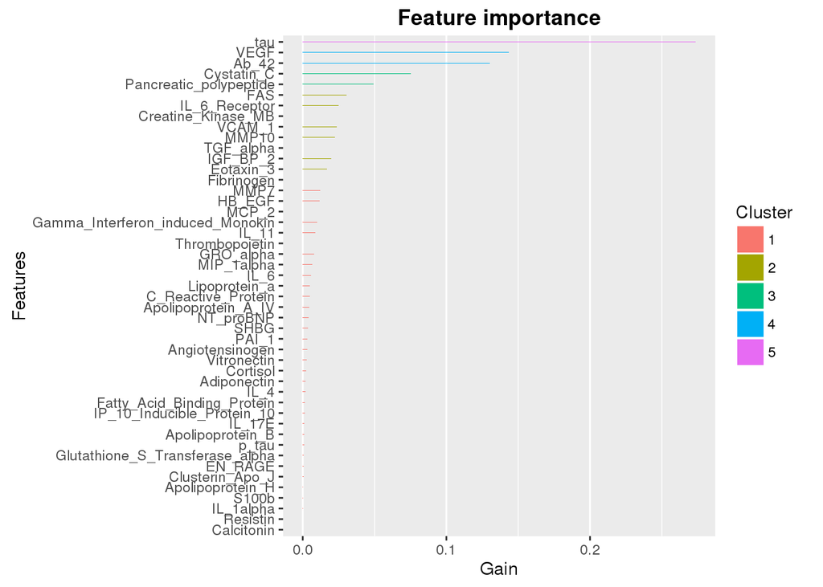

```r
#install.packages('Ckmeans.1d.dp')
library(Ckmeans.1d.dp)
xgb.plot.importance(importance)
```

# Testing Model

## Predictions

Make predictions on test set.

```r
predictions <- predict(model, ad_matrix[-train_index,])
predictions <- as.numeric(predictions > 0.5)
table(predictions)
```

```
## predictions
##   0   1
## 107  26
```

```r
table(diagnosis[-train_index])
```

```
##
##   0   1
## 101  32
```

## Confusion Matrix

```r
confusionMatrix(predictions, diagnosis[-train_index])
```

```
## Confusion Matrix and Statistics
##
##           Reference
## Prediction  0  1
##          0 96 11
##          1  5 21
##
##                Accuracy : 0.8797
##                  95% CI : (0.812, 0.9296)
##     No Information Rate : 0.7594
##     P-Value [Acc > NIR] : 0.0003953
##
##                   Kappa : 0.6483
##  Mcnemar's Test P-Value : 0.2112995
##
##             Sensitivity : 0.9505
##             Specificity : 0.6562
##          Pos Pred Value : 0.8972
##          Neg Pred Value : 0.8077
##              Prevalence : 0.7594
##          Detection Rate : 0.7218
##    Detection Prevalence : 0.8045
##       Balanced Accuracy : 0.8034
##
##        'Positive' Class : 0
##
```

```r
error <- mean(predictions != diagnosis[-train_index])
```

Test Error: 0.1203008

# References

[1] Craig-Schapiro, R., Kuhn, M., Xiong, C., Pickering, E. H., Liu, J., Misko, T. P., … Holtzman, D. M. (2011). Multiplexed Immunoassay Panel Identifies Novel CSF Biomarkers for Alzheimer’s Disease Diagnosis and Prognosis. PLoS ONE, 6(4), e18850. http://doi.org/10.1371/journal.pone.0018850

[2] Tianqi Chen, Tong He and Michael Benesty (2016). xgboost: Extreme Gradient Boosting. R package version 0.4-3. https://CRAN.R-project.org/package=xgboost

[3] Max Kuhn. Contributions from Jed Wing, Steve Weston, Andre Williams, Chris Keefer, Allan Engelhardt, Tony Cooper, Zachary Mayer, Brenton Kenkel, the R Core Team, Michael Benesty, Reynald Lescarbeau, Andrew Ziem, Luca Scrucca, Yuan Tang and Can Candan. (2016). caret: Classification and Regression Training. R package version 6.0-68. https://CRAN.R-project.org/package=caret

Max Kuhn and Kjell Johnson (2014). AppliedPredictiveModeling: Functions and Data Sets for ‘Applied Predictive Modeling’. R package version 1.1-6. https://CRAN.R-project.org/package=AppliedPredictiveModeling